# Funciones de activación

Existe en una parte del perceptrón y nos sirven para darle valores de salida diferente, a toda la combinación de entrada lineal del perceptrón.

Vamos a ver como se utilizan estas funciones de activación y como se implementan al final del perceptrón.

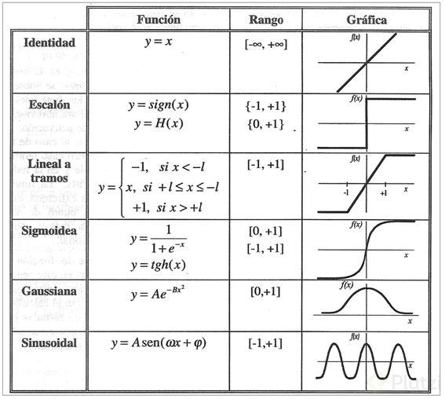

```python
import numpy as np
import matplotlib.pyplot as plt

#Configurando Latex
# Configuración de Matplotlib para usar LaTeX
plt.rcParams.update({
    "text.usetex": True,
    "font.family": "serif",
    "font.serif": ["Computer Modern Roman"],
    "text.latex.preamble": r"\usepackage{amsmath}"
})
```

## Función lineal

$$f(x)=mx+b$$

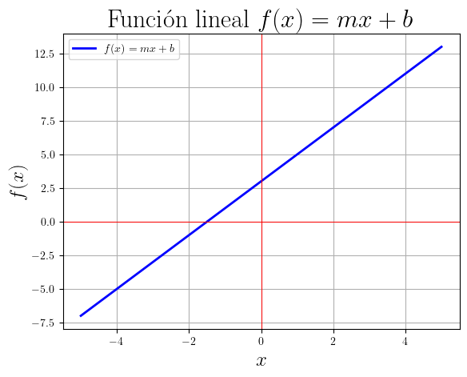

```python
# definiendo funcion parabola
def f(m,x,b):
  return m*x+b

#Definiendo variables
N = 1000
x = np.linspace(-5,5, num=N)

#Creando graficas
fig, ax = plt.subplots()
ax.plot(x,f(2,x,3),label=r'$f(x)=mx+b$',color='blue',linewidth=2)
ax.grid()
ax.axhline(y=0, color='r',linewidth=0.7)
ax.axvline(x=0, color='r',linewidth=0.7)
plt.title(r'Función lineal $f(x)=mx+b$',fontsize=23)
plt.xlabel(r'$x$',fontsize=18)
plt.ylabel(r'$f(x)$',fontsize=18)
plt.legend()
plt.show()
```

## Función escalón o de Heaviside

$$H(x) = \begin{cases} 0, &\quad \text{para, } x < 0 \\ 1, &\quad\text{para. } x \ge 0 \\ \end{cases} $$

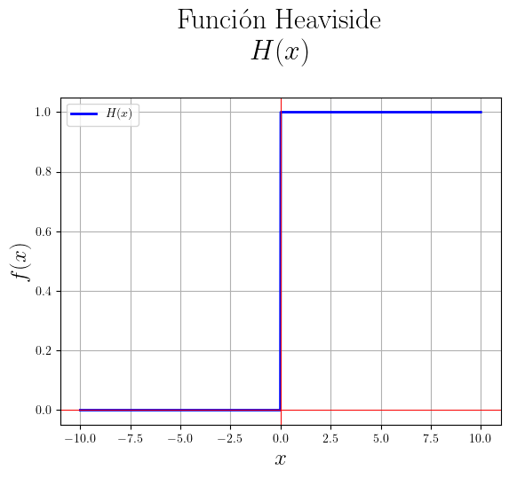

```python
def H(x):
  Y = np.zeros(len(x))
  for idx,x in enumerate(x):
    if x>=0:
      Y[idx]=1
  return Y


N=1000
x = np.linspace(-10,10, num=N)
y = H(x)
fig, ax = plt.subplots()
plt.plot(x,y,label=r'$H(x)$',color='blue',linewidth=2)
plt.grid()
ax.axhline(y=0, color='r',linewidth=0.7)
ax.axvline(x=0, color='r',linewidth=0.7)
plt.title(f'Función Heaviside\n$H(x)$\n',fontsize=23)
plt.xlabel(r'$x$',fontsize=18)
plt.ylabel(r'$f(x)$',fontsize=18)
plt.legend()
plt.show()
```

### ¿Para qué sirve?

Para poder **hacer clasificaciones categóricas**, esto nos podría indicar si algo está `[prendido,apagado],[existe, no existe]` es decir para jugar con valores binarios.  
Esto en modelos de clasifican super sencillos es de gran utilidad.

## Función Sigmoide

$$f(x)=\frac{1}{1+e^{-x}}$$

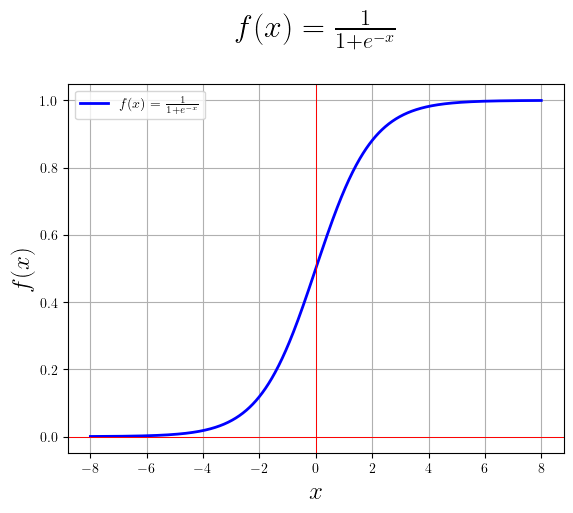

```python
def f(x):
  return 1/(1 + np.exp(-x))


N=1000
x = np.linspace(-8,8, num=N)
y = f(x)

fig, ax = plt.subplots()
plt.plot(x,y,label=r'$f(x)=\frac{1}{1+e^{-x}}$',color='blue',linewidth=2)
plt.grid()
ax.axhline(y=0, color='r',linewidth=0.7)
ax.axvline(x=0, color='r',linewidth=0.7)
plt.title(r'$f(x)=\frac{1}{1+e^{-x}}$'+'\n',fontsize=23)
plt.xlabel(r'$x$',fontsize=18)
plt.ylabel(r'$f(x)$',fontsize=18)
plt.legend()
plt.show()
```

### ¿Para qué sirve?

Para un **modelo de regresión logistica** y ¿por qué? sobre todo cuando hablamos de probabilidades.

> Porqué su **rango** va de $0-1$ y las probabilidades también van de *0 a 1*

**IMPORTANTE**  
cuando el valor de $X=0$ el valor de $Y=0.5$

## Función tangente hiperbólica

$$f(x)=\frac{2}{1+e^{-2x}}-1$$

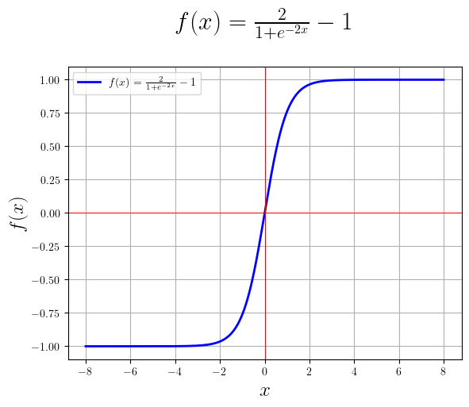

```python
def f(x):
  return np.tanh(x)


N=1000
x = np.linspace(-8,8, num=N)
y = f(x)

fig, ax = plt.subplots()
plt.plot(x,y,label=r'$f(x)=\frac{2}{1+e^{-2x}}-1$',color='blue',linewidth=2)
plt.grid()
ax.axhline(y=0, color='r',linewidth=0.7)
ax.axvline(x=0, color='r',linewidth=0.7)
plt.title(r'$f(x)=\frac{2}{1+e^{-2x}}-1$'+'\n',fontsize=23)
plt.xlabel(r'$x$',fontsize=18)
plt.ylabel(r'$f(x)$',fontsize=18)
plt.legend()
plt.show()
```

### ¿Para qué sirve?

También se le conoce como una función de escalamiento y va a tener los valores de $-1$ a $1$.

> Esta función tiene un problema con el algoritmo **bad propagation**. Siguen un patrón similar al `sigmoide`.

## Función ReLU

$$R(x)=max(0,x)$$

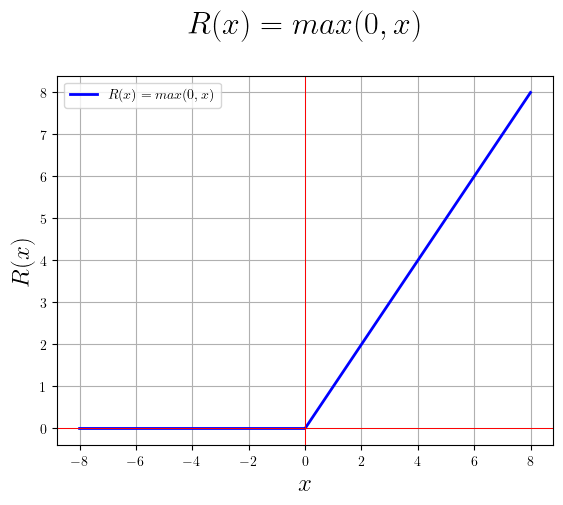

```python
def f(x):
  return np.maximum(x,0)


N=1000
x = np.linspace(-8,8, num=N)
y = f(x)

fig, ax = plt.subplots()
plt.plot(x,y,label=r'$R(x)=max(0,x)$',color='blue',linewidth=2)
plt.grid()
ax.axhline(y=0, color='r',linewidth=0.7)
ax.axvline(x=0, color='r',linewidth=0.7)
plt.title(r'$R(x)=max(0,x)$'+'\n',fontsize=23)
plt.xlabel(r'$x$',fontsize=18)
plt.ylabel(r'$R(x)$',fontsize=18)
plt.legend()
plt.show()
```

### ¿Para qué sirve?

Significa que si; $$R(x) = \begin{cases} 0, &\quad \text{para, } x < 0 \\ x, &\quad\text{para. } x \ge 0 \\ \end{cases} $$

En otras palabras para valores de $x<0;R(x)=0$ para valores de $x$ menores a $0$ la función vale $0$, por otro lado para valores de $x>0;R(x)$ para valores de $x$ mayores a $0$ la función vale $x, es decir va a empezar a existir un crecimiento.

> A esta función se le pone al final de un perceptrón, cuando nosotros queremos simular un proceso de neuronas muertas (cuando los valores tienden a ser $0$ o negativos *es decir no existentes para el proceso que nosotros realizamos con nuestro modelo* y cuando tenemos un valor que si pueda procesar; es decir mayor a cero, entonces si vamos a tomar el valor a procesar).

#### Digamos que la neurona va decir: ¿Existe? entonces lo tomo en cuenta, ¿no existe? entonces lo pongo como cero.

> Existe una variación de esta función que se llama Leaky RELU; lo que hace es que en los valores donde está el 0, los pone con una ligera pendiente, para que exista una pequeña ponderación.

# Extra:

- [Funciones de activacion](https://www.youtube.com/watch?v=_0wdproot34)
- [Funciones de activacion](https://ichi.pro/es/funciones-de-activacion-conceptos-basicos-de-sigmoid-relu-leaky-relu-y-softmax-para-redes-neuronales-y-aprendizaje-pr-155703049115934)
- [Diferencias](https://datascience.stackexchange.com/questions/102483/difference-between-relu-elu-and-leaky-relu-their-pros-and-cons-majorly)
- [Post](https://lamaquinaoraculo.com/deep-learning/la-funcion-de-activacion/)